# Homework 5

Devin Warner

2022-03-24

## Question 1

Suppose $\mathbf{x} = (x_1,...,x_N)^T$ follow a Poisson distribution with a parameter $\lambda > 0$ and p.m.f given by

$$P(x = k | \lambda) =
\frac{\lambda^ke^{-\lambda}}{k!}$$

Answer the following questions:

1. Using $\mathbf{ggplot}$, plot the Poisson pmf for k = 0,1,…,10 when $\lambda = 5$.

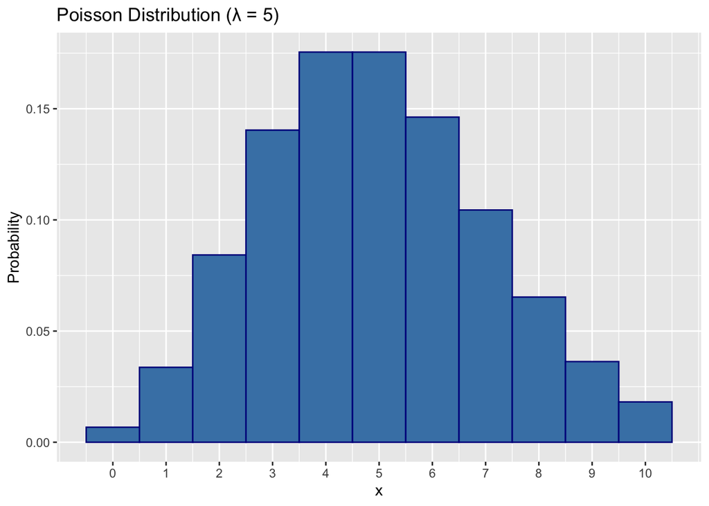

```r
## a
data_pois <- tibble("x_pois" = c(0:10), "y_pois" = dpois(c(0:10), 5))

ggplot(data_pois, aes(x = x_pois, y = y_pois)) +
  geom_col(width = 1, fill = "steelblue", color = "darkblue") +
  scale_x_continuous(breaks = data_pois$x_pois) +
  labs(x ="x", y = "Probability", title = "Poisson Distribution (\u03BB = 5)")
```

2. Assuming **x** is observed, give the likelihood $L(\lambda | \mathbf{x})$ and log-likelihood $l(\lambda | \mathbf{x})$ functions.

$$L(\lambda | \mathbf{x}) =
\Pi_{i=1}^{n}[\frac{\lambda^{x_i}e^{-\lambda}}{x_i!}]=\frac{\lambda^{\Sigma_{i=1}^n[x_i]}e^{-n\lambda}}{\Pi_{i=1}^{n}[x_i!]}$$

$$l(\lambda | \mathbf{x}) = \ln(L(\lambda
| \mathbf{x})) = \ln(\lambda^{\Sigma_{i=1}^n[x_i]}) + \ln(-n\lambda) -
\ln(\Pi_{i=1}^{n}[x_i!]) = \Sigma_{i=1}^n[x_i]\ln(\lambda) - n\lambda -
\ln(\Pi_{i=1}^{n}[x_i!])$$

3. Find the Maximum LIkelihood Estimate (MLE) $\hat{\lambda}$ for $\lambda$.

$$\frac{d}{d\lambda} l(\lambda |
\mathbf{x}) = \frac{\Sigma_{i=1}^n[x_i]}{\lambda} - n$$

Set equal to zero to solve for MLE.

$$0
= \frac{\Sigma_{i=1}^n[x_i]}{\hat{\lambda}} - n \rightarrow
\hat{\lambda} = \frac{\Sigma_{i=1}^n[x_i]}{n}$$

4. Show that your estimator is in fact a maximum.

Checking Second-Derivative

$$\frac{d^2}{d\lambda^2} l(\lambda |
\textbf{x}) = -\frac{\Sigma_{i=1}^n[x_i]}{\lambda^2}$$

The second derivative of the log-likelihood function is non-positive everywhere since $\lambda >0$ and $x \geq 0$ for all $x \in \mathbf{x}$. Thus, the log-likelihood function in concave down everywhere, and our extrema is a maximum.

## Question 2

Suppose $\mathbf{x} = (x_1,...,x_N)^T$ are *iid* random variables with p.d.f given by

$$f(x|\theta) = \theta x^{\theta -1}, 0
\leq x \leq 1, 0 < \theta < \infty$$

1. Using **ggplot**, plot the pdf for an individual $x_i$ given $\theta = 0.5$ and also for $\theta = 5$.

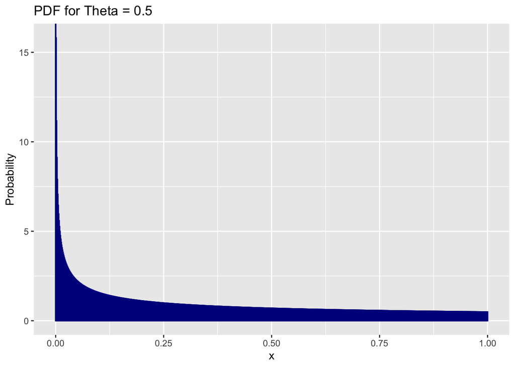

```r
x <- seq(0,1,0.001)
y1 <- 0.5*(x^(0.5-1))
y2 <- 5*(x^(5-1))
dist <- tibble(x,y1,y2)

dist %>%
  ggplot(aes(x = x, y = y1)) +
  geom_col(width = 0.001, fill = "darkblue", color = "darkblue") +
  labs(x = "x", y = "Probability", title = "PDF for Theta = 0.5")
```

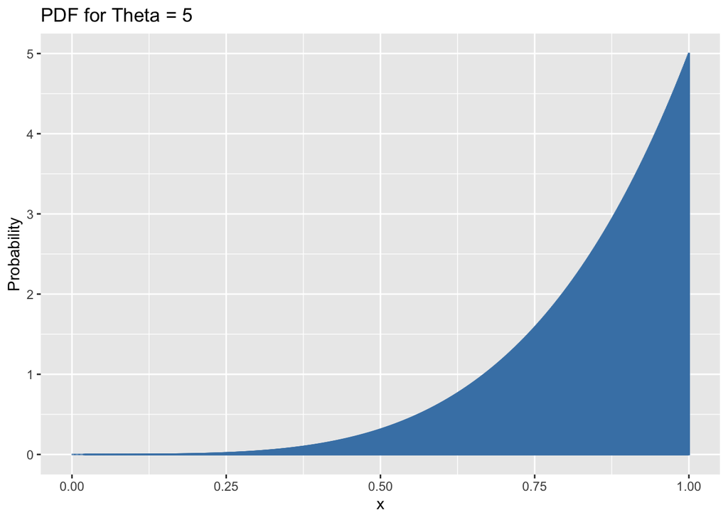

```r
dist %>%
  ggplot(aes(x = x, y = y2)) +
  geom_col(width = 0.001, fill = "steelblue", color = "steelblue") +
  labs(x = "x", y = "Probability", title = "PDF for Theta = 5")
```

2. Give the likelihood $L(\lambda | \mathbf{x})$ and log-likelihood $l(\lambda | \mathbf{x})$ functions.

$$L(\theta | \mathbf{x}) = \Pi_{i
=1}^n[\theta x_i^{\theta-1}] = \theta^n \Pi_{i
=1}^n[x_i^{\theta-1}]$$
Important fact, the product of values inside a log is equal to the sum of the log of each of the values

$$l(\theta | \mathbf{x}) = n\ln(\theta) +
(\theta -1)\Sigma_{i=1}^n[\ln(x_i)]$$
c) Find the Maximum Likelihood Estimator (MLE) $\hat{\theta}$ for $\theta$.

$$\frac{d}{d\theta} l(\theta |
\mathbf{x}) = \frac{n}{\theta} +
\Sigma_{i=1}^n[\ln(x_i)]$$

Set equal to zero to solve for MLE.

$$0 = \frac{n}{\hat{\theta}} +
\Sigma_{i=1}^n[\ln(x_i)] \rightarrow \hat{\theta} =
\frac{-n}{\Sigma_{i=1}^n[\ln(x_i)]} \text{ where } x_i \in (0,1)
\forall i =1,2,3,...,n$$

4. Show that your estimator is in fact a maximum.

Checking Second Derivative

$$\frac{d^2}{d\theta^2} l(\theta |
\textbf{x}) = -\frac{n}{\theta^2}$$

We see that the second derivative of the log-likelihood function is non-positive everywhere (for all values of $\theta$) since $\theta^2 \geq 0$ and $n \geq 0$. Thus, our log-likelihood function is concave down everywhere, and our extrema is a maximum.

## Question 3

Suppose $\mathbf{x} = (x_1,...,x_N)^T$ are *iid* random variables from a $Normal(0,\sigma^2)$ distribution. The pdf is given by

$$f(x | \sigma^2) =
(\frac{1}{2\pi\sigma^2})^{1/2}e^{-\frac{x^2}{2\sigma^2}}$$

Find the Maximum Likelihood Estimator (MLE) $\hat{\sigma}^2$ for $\sigma^2$. Is it what you thought it would be? Why or why not?

**Answer:**

The likelihood and log-likelihood:

$$L(\sigma^2 | \mathbf{x}) =
\Pi_{i=1}^n[(\frac{1}{2\pi\sigma^2})^{1/2}e^{-\frac{x_i^2}{2\sigma^2}}]
= (\frac{1}{2\pi\sigma^2})^{n/2}e^{-\frac{\Sigma_{i=1}^n
x_i^2}{2\sigma^2}}$$

$$l(\sigma^2 | \mathbf{x}) =
\frac{n}{2}\ln(\frac{1}{2\pi\sigma^2})- \frac{\Sigma_{i=1}^n
x_i^2}{2\sigma^2}\ln(e) = -\frac{n}{2}\ln(2\pi\sigma^2) -
\frac{\Sigma_{i=1}^n x_i^2}{2\sigma^2}$$

Find the derivative of the log-likelihood

$$\frac{d}{d\sigma^2}l(\sigma^2 |
\mathbf{x}) = -\frac{n}{2\sigma^2} + \frac{\Sigma_{i=1}^n
x_i^2}{2(\sigma^2)^2}$$

Set equal to zero to find MLE for $ $ for $\sigma^2$

$$0 =-\frac{n}{2\hat{\sigma}^2} +
\frac{\Sigma_{i=1}^n x_i^2}{2(\hat{\sigma}^2)^2}$$
$$\frac{n}{2\hat{\sigma}^2} = \frac{\Sigma_{i=1}^n
x_i^2}{2(\hat{\sigma}^2)^2}$$
$$\hat{\sigma}^2 = \frac{\Sigma_{i=1}^n x_i^2}{n}$$
My mind is blown. This is exactly what I have been taught the equation for sample variance is for a normal distribution with a mean of zero. I am overjoyed that I have just derived it.